# Introduction to generalized linear models

11 May 2026

## Goals for today

- Understand the 3 elements of a generalized linear model
- Understand how to identify the proper distribution for a generalized linear model
- Understand the concept of a link function

## Forms of linear models

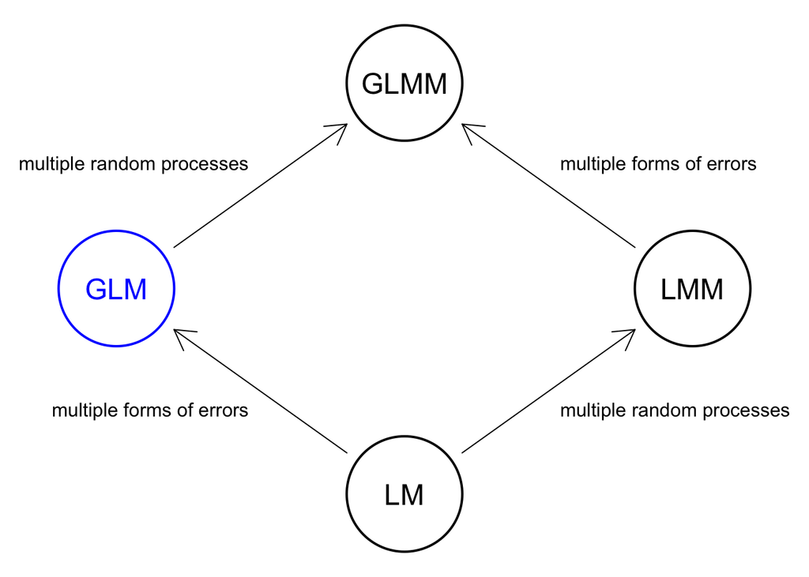

## Ecological data

### At the individual level

1 Detection \(\rightarrow\) presence/absence

2+ Detections \(\rightarrow\) survival, movement

## Ecological data

### At the individual level

1 Detection \(\rightarrow\) presence/absence

2+ Detections \(\rightarrow\) survival, movement

1 Measurement \(\rightarrow\) fecundity, age, size

2+ Measurements \(\rightarrow\) growth

## Ecological data

### At the population level

Detections \(\rightarrow\) presence/absence

Counts \(\rightarrow\) density or survival/movement

## Data types

### Discrete values

Sex

Age

Fecundity

Counts/Census

Survival (individual)

## Discrete data

Given the prevalence of discrete data in ecology (and elsewhere), we seek a means for modeling them

## Generalized linear models (GLMs)

GLMs were developed by Nelder & Wedderburn in the 1970s

They include (as special cases):

- linear regression
- ANOVA
- logit models
- log-linear models
- multinomial models

## Generalized linear models (GLMs)

In particular, GLMs can explicitly model discrete data as outcomes

## A very important question

What is the distributional form of the random process(es) in my data?

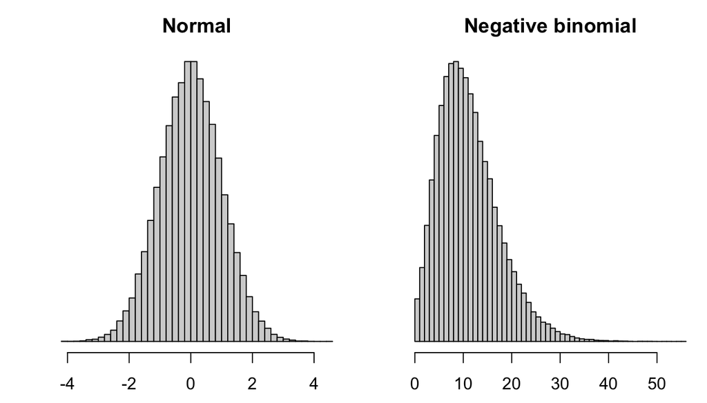

## Distribution for discrete counts

The Poisson distribution is perhaps the best known

It gives the probability of a given number of events occurring in a fixed interval of time or space

## Poisson distribution

### Examples

- the number of rabbits seen outside my office window each day
- the number of fish caught in a 15-minute bottom trawl
- the number of email messages I receive per week from students in QERM 514

## Poisson distribution

Has *only one* parameter \(\lambda\) to describe both the mean *and* variance

\[ y_i \sim \text{Poisson}(\lambda) \] \[ \text{Mean}(y) = \text{Var}(y) = \lambda \]

## Distribution for the ratio of counts

Ratios (fractions) are also very important in ecology

They convey proportions such as

- survivors / tagged individuals
- infected / susceptible
- student emails / total emails

## Distribution for the ratio of counts

The simplest ratio has as denominator of 1 and a numerator of either 0 or 1

For an individual, this can represent

- present (1/1) or absent (0/1)
- alive (1/1) or dead (0/1)
- mature (1/1) or immature (0/1)

## Bernoulli distribution

The Bernoulli distribution describes the probability of a *single event* \(y_i\) occurring

\[ y_i \sim \text{Bernoulli}(p) \]

where

\[ \text{Mean}(y) = p \\ ~ \\ \text{Var}(y) = p(1 - p) \]

## Binomial distribution

The binomial distribution is closely related to the Bernoulli

It describes the number of “successes” \((k)\) in a sequence of \(n\) independent Bernoulli “trials”

For example, the number of heads in 4 coin tosses

## Binomial distribution

For a population, these could be

- \(k\) survivors out of \(n\) tagged individuals
- \(k\) infected individuals out of \(n\) susceptible individuals
- \(k\) counts of allele A in \(n\) total chromosomes

## Generalized linear models (GLMs)

*Three important components*

1. Distribution of the data

Are they counts, proportions?

## Generalized linear models (GLMs)

*Three important components*

1. Distribution of the data
2. Link function \(g\)

Specifies the relationship between mean of the distribution and some linear predictor(s)

## Generalized linear models (GLMs)

*Three important components*

1. Distribution of the data
2. Link function \(g\)
3. Linear predictor \(\eta\)

\(\eta = \mathbf{X} \boldsymbol{\beta}\)

## Common link functions

| Distribution | Link function | Mean function |
| --- | --- | --- |
| Normal | *Identity*: \(1(\mu) = \mathbf{X} \boldsymbol{\beta}\) | \(\mu = \mathbf{X} \boldsymbol{\beta}\) |
| Poisson | *Log*: \(\log (\mu) = \mathbf{X} \boldsymbol{\beta}\) | \(\mu = \exp (\mathbf{X} \boldsymbol{\beta})\) |
| Binomial | *Logit*: \(\log \left( \frac{\mu}{1 - \mu} \right) = \mathbf{X} \boldsymbol{\beta}\) | \(\mu = \frac{\exp (\mathbf{X} \boldsymbol{\beta})}{1 + \exp (\mathbf{X} \boldsymbol{\beta})}\) |

## Common link functions

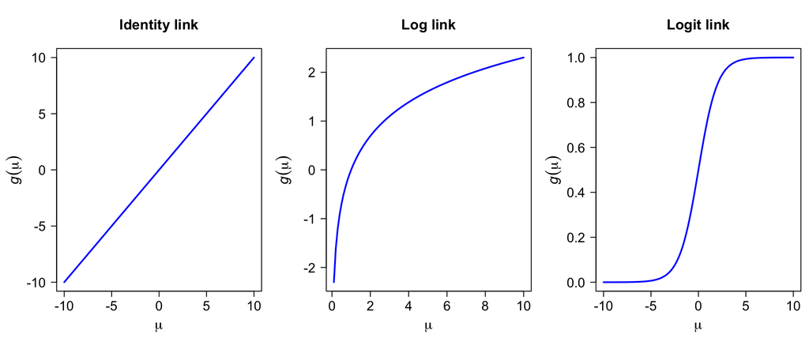

## Canonical links

Where did we find these link functions?

For the exponential family of distributions (eg, Normal, Gamma, Poisson) we can write out the distribution of \(y\) as

\[ f(y; \theta, \phi) = \exp \left( \frac{y \theta - b(\theta)}{a(\phi)} - c(y, \phi)\right) \]

\(\theta\) is the *conanical* parameter of interest

\(\phi\) is a scale (variance) parameter

## Exponential family

\[ f(y; \theta, \phi) = \exp \left( \frac{y \theta - b(\theta)}{a(\phi)} - c(y, \phi)\right) \]

We seek some *canonical* function \(g\) that connects \(\eta\), \(\mu\), and \(\theta\) such that

\[ g(\mu) = \eta \\ \eta \equiv \theta \]

## Normal distribution

\[ f(y; \theta, \phi) = \exp \left( \frac{y \theta - b(\theta)}{a(\phi)} - c(y, \phi)\right) \\ \Downarrow \\ f(y; \mu, \sigma) = \frac{1}{\sqrt{2 \pi \sigma}} \exp \left( \frac{(y - \mu)^2}{2 \sigma^2} \right)\\ \]

with \(\theta = \mu\) and \(\phi = \sigma^2\)

\(a(\phi) = \phi ~~~~~~ b(\theta) = \frac{\theta^2}{2} ~~~~~~ c(y, \phi) = - \frac{\tfrac{y^2}{\phi} + \log (2 \pi \phi)}{2}\)

## Normal distribution

\[ f(y; \theta, \phi) = \exp \left( \frac{y \theta - b(\theta)}{a(\phi)} - c(y, \phi)\right) \\ \Downarrow \\ f(y; \mu, \sigma) = \frac{1}{\sqrt{2 \pi \sigma}} \exp \left( \frac{(y - \mu)^2}{2 \sigma^2} \right)\\ \]

with \(\theta = 1(\mu)\) and \(\phi = \sigma^2\)

\(a(\phi) = \phi ~~~~~~ b(\theta) = \frac{\theta^2}{2} ~~~~~~ c(y, \phi) = - \frac{\tfrac{y^2}{\phi} + \log (2 \pi \phi)}{2}\)

## Poisson distribution

\[ f(y; \theta, \phi) = \exp \left( \frac{y \theta - b(\theta)}{a(\phi)} - c(y, \phi)\right) \\ \Downarrow \\ f(y; \mu) = \frac{\exp (- \mu) \mu^y}{y!} \\ \]

with \(\theta = \log (\mu)\) and \(\phi = 1\)

\(a(\phi) = 1 ~~~~~~ b(\theta) = \exp (\theta) ~~~~~~ c(y, \phi) = - \log (y!)\)

## Binomial distribution

For the binomial distribution there are several possible link functions

- logit
- probit
- complimentary log-log

## Generalized linear models (GLMs)

The word *generalized* means these models are broadly applicable

For example, GLMs include linear regression models

## Writing an LM as a GLM

\[ y_i = \alpha + \beta x_i + \epsilon_i \\ \epsilon_i \sim \text{N}(0,\sigma^2) \]

## Writing an LM as a GLM

\[ y_i = \alpha + \beta x_i + \epsilon_i \\ \epsilon_i \sim \text{N}(0,\sigma^2) \\ \Downarrow \\ y_i = \mu_i + \epsilon_i \\ \mu_i = \alpha + \beta x_i \\ \epsilon_i \sim \text{N}(0,\sigma^2) \]

## Writing an LM as a GLM

\[ y_i = \mu_i + \epsilon_i \\ \mu_i = \alpha + \beta x_i \\ \epsilon_i \sim \text{N}(0,\sigma^2) \\ \Downarrow \\ y_i = \epsilon_i \\ \mu_i = \alpha + \beta x_i \\ \epsilon_i \sim \text{N}(\mu_i,\sigma^2) \]

## Writing an LM as a GLM

\[ y_i = \epsilon_i \\ \mu_i = \alpha + \beta x_i \\ \epsilon_i \sim \text{N}(\mu_i,\sigma^2) \\ \Downarrow \\ y_i \sim \text{N}(\mu_i,\sigma^2) \\ \mu_i = \alpha + \beta x_i \]

## Writing an LM as a GLM

\[ y_i \sim \text{N}(\mu_i,\sigma^2) \\ \mu_i = \alpha + \beta x_i \\ \Downarrow \\ y_i \sim \text{N}(\mu_i,\sigma^2) \\ 1(\mu_i) = \mu_i \\ \mu_i = \alpha + \beta x_i \]

## Writing an LM as a GLM

\[ y_i \sim \text{N}(\mu_i,\sigma^2) \\ 1(\mu_i) = \mu_i \\ \mu_i = \alpha + \beta x_i \\ \Downarrow \\ \begin{aligned} \text{data distribution:} & ~~ y_i \sim \text{N}(\mu_i,\sigma^2) \\ \\ \text{link function:} & ~~ 1(\mu_i) = \mu_i \\ \\ \text{linear predictor:} & ~~ \mu_i = \alpha + \beta x_i \end{aligned} \]

## Example of a GLM

Log-density of live trees per unit area \(y_i\) as a function of fire intensity \(F_i\)

\[ \begin{aligned} \text{data distribution:} & ~~ y_i \sim \text{N}(\mu_i,\sigma^2) \\ \\ \text{link function:} & ~~ 1(\mu_i) = \mu_i \\ \\ \text{linear predictor:} & ~~ \mu_i = \alpha + \beta F_i \end{aligned} \]

## Rethinking density

We have been considering (log) density itself as a response

\[ \text{Density}_i = f (\text{Count}_i, \text{Area}_i) \\ \Downarrow \\ \text{Density}_i = \frac{\text{Count}_i}{\text{Area}_i} \\ \]

## Rethinking density

With GLMs, we can shift our focus to counts as a function of area

\[ \text{Count}_i = f (\text{Area}_i) \]

## Example of a GLM

Counts of live trees \(y_i\) as a function of area surveyed \(A_i\) and fire intensity \(F_i\)

\[ \begin{aligned} \text{data distribution:} & ~~ y_i \sim \text{Poisson}(\lambda_i) \\ \\ \text{link function:} & ~~ \text{log}(\lambda_i) = \mu_i \\ \\ \text{linear predictor:} & ~~ \mu_i = \alpha + \beta_1 A_i + \beta_2 F_i \end{aligned} \]

## Example of a GLM

Probability of spotting a sparrow \(p_i\) as a function of vegetation height \(H_i\)

\[ \begin{aligned} \text{data distribution:} & ~~ y_i \sim \text{Bernoulli}(p_i) \\ \\ \text{link function:} & ~~ \text{logit}(p_i) = \text{log}\left(\frac{p_i}{1-p_i}\right) = \mu_i \\ \\ \text{linear predictor:} & ~~ \mu_i = \alpha + \beta H_i \end{aligned} \]

## Example of a GLM

Survival \(s_i\) of \(N_i\) salmon eggs to \(y_i\) fry as a function of water temperature \(T_i\)

\[ \begin{aligned} \text{data distribution:} & ~~ y_i \sim \text{Binomial}(N_i, s_i) \\ \\ \text{link function:} & ~~ \text{logit}(s_i) = \text{log}\left(\frac{s_i}{1-s_i}\right) = \mu_i \\ \\ \text{linear predictor:} & ~~ \mu_i = \alpha + \beta T_i \end{aligned} \]

## Summary

There are three important components to GLMs

1. Distribution of the data
2. Link function \(g\)
3. Linear predictor \(\eta\)